# Reference & Exercise

# Day 1 Practice

## Session 1 & 2

### Exercise 1: Simple Calculations

- Use R to calculate the following:
  - multiply 31 and 78
  - divide 697 with 41
- Assign the value of 39 to x
- Assign the value of 22 to y

```r
31 * 78
```

```
## [1] 2418
```

```r
697 / 41
```

```
## [1] 17
```

```r
x <- 39
x
```

```
## [1] 39
```

```r
y <- 22
y
```

```
## [1] 22
```

### Exercise 2: Working with Vectors

- Create a vector called `newvec` with 20 elements
- add names to the elements
- retrieve 1st 5 elements
- retrieve any 3 elements by name

```r
myvec <- c(1:20)

names(myvec) <- LETTERS[1:20]

myvec
```

```
##  A  B  C  D  E  F  G  H  I  J  K  L  M  N  O  P  Q  R  S  T
##  1  2  3  4  5  6  7  8  9 10 11 12 13 14 15 16 17 18 19 20
```

```r
myvec[1:5]
```

```
## A B C D E
## 1 2 3 4 5
```

```r
myvec[c(1,4,6)]
```

```
## A D F
## 1 4 6
```

### Exercise 3: Lists and Data Frames

- Write a R program to create a list of dataframes and access each of those data frames from the list.
- Create a data frame from a matrix of your choice, change the row names so every row says id_i (where i is the row number) and change the column names to variable_i (where i is the column number). I.e., for column 1 it will say variable_1, and for row 2 will say id_2 and so on.

```r
mylist <- list(data.frame("one"=1:10,"two"=11:20,"three"=21:30),
               data.frame("A"=letters[1:5],"B"=letters[6:10],"C"=letters[11:15] )
)

mylist
```

```
## [[1]]
##    one two three
## 1    1  11    21
## 2    2  12    22
## 3    3  13    23
## 4    4  14    24
## 5    5  15    25
## 6    6  16    26
## 7    7  17    27
## 8    8  18    28
## 9    9  19    29
## 10  10  20    30
##
## [[2]]
##   A B C
## 1 a f k
## 2 b g l
## 3 c h m
## 4 d i n
## 5 e j o
```

```r
mylist[[1]]
```

| one | two | three |
| --- | --- | --- |
| 1 | 11 | 21 |
| 2 | 12 | 22 |
| 3 | 13 | 23 |
| 4 | 14 | 24 |
| 5 | 15 | 25 |
| 6 | 16 | 26 |
| 7 | 17 | 27 |
| 8 | 18 | 28 |
| 9 | 19 | 29 |
| 10 | 20 | 30 |

```r
mylist[[2]]
```

| A | B | C |
| --- | --- | --- |
| a | f | k |
| b | g | l |
| c | h | m |
| d | i | n |
| e | j | o |

```r
mymatrix <- matrix(1:100,nrow = 20, ncol = 5)
mydf <- data.frame(mymatrix)
colnames(mydf) <- paste0("variable_",1:ncol(mydf))
rownames(mydf) <- paste0("id_",rownames(mydf))
mydf
```

|  | variable_1 | variable_2 | variable_3 | variable_4 | variable_5 |
| --- | --- | --- | --- | --- | --- |
| id_1 | 1 | 21 | 41 | 61 | 81 |
| id_2 | 2 | 22 | 42 | 62 | 82 |
| id_3 | 3 | 23 | 43 | 63 | 83 |
| id_4 | 4 | 24 | 44 | 64 | 84 |
| id_5 | 5 | 25 | 45 | 65 | 85 |
| id_6 | 6 | 26 | 46 | 66 | 86 |
| id_7 | 7 | 27 | 47 | 67 | 87 |
| id_8 | 8 | 28 | 48 | 68 | 88 |
| id_9 | 9 | 29 | 49 | 69 | 89 |
| id_10 | 10 | 30 | 50 | 70 | 90 |

[output cut: 10 more lines]

### Exercise 4: Reading & Writing

- load `iris` data. save the dataframe in .csv, .tsv and .xls format

```r
data(iris)

write.csv(iris, file = "irisdata.csv")

write.table(iris, file = "irisdata.tsv", sep = "\t", quote = FALSE, row.names = FALSE)

library(openxlsx)
write.xlsx(iris, file = "irisdata.xlsx", colNames = TRUE, borders = "columns")
```

## Session 3

### Exercise 5 [simple]

Draw a scatterplot of Petal.Length versus Sepal.Length.

Then mark the mean Petal.Length of each species by a dashed vertical line. Give each line its own color.

Hints:

- The means are pre-computed in the “How To Draw a Bar Chart” example. You can extract the Petal.Length means from the respective column of `df`.
- Use `?par` to see the Graphical Parameters help page. Parameter `lty` sets the line type

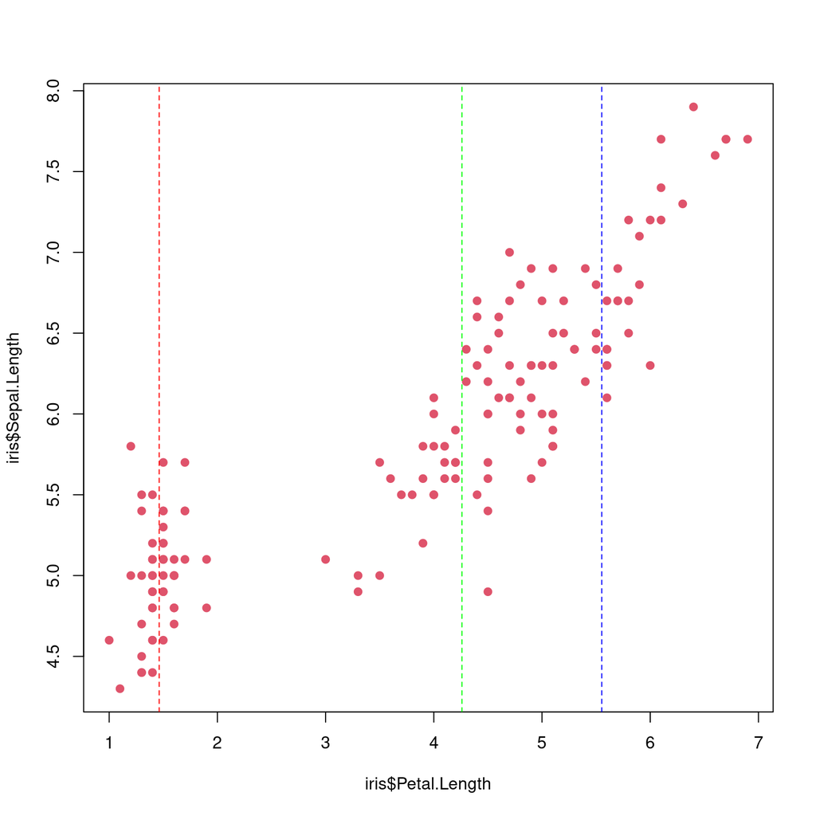

```r
## The code of the example:
df <- aggregate(
        iris[,1:4],
        by = list(iris$Species),
        FUN = mean)

# Get the means from the example df:
m <- df$Petal.Length

# Draw the scatterplot:
plot(iris$Petal.Length,
     iris$Sepal.Length,
     pch=19, col=2)

# Draw the lines:
abline(v=m,
       col=c("red","green","blue"),
       lty=2)
```

### Exercise 6 [medium]

Draw a scatterplot of Petal.Length versus Sepal.Length. Color the points by species.

Then mark the point (x=mean(Petal.Length), y=mean(Sepal.Length)) of each species with fat points on the plot. Color each point color according to its species.  
Put the names of the species as text labels next to the points. Add a title to the plot.

Hints:

- The means are pre-computed in the “How To Draw a Bar Chart” example. You can extract the Petal.Length means from the respective column of `df`.
- The `col` parameter of `plot()` can take a vector argument, assigning an individual color to each point. To construct this vector from the Species column
  - first define a mapping from species to colors (a vector, where each element is a color and each element name is a species)
  - then index this vector with the Species column
- Use `?par` to see the Graphical Parameters help page. Parameter `cex` changes the point size. Use ?base::plot to see the help page of the plot function. Parameter “main” sets the title.

```r
## The code of the example:
df <- aggregate(
        iris[,1:4],
        by = list(iris$Species),
        FUN = mean)

# Get the means from the example df:
mPL <- df$Petal.Length
mSL <- df$Sepal.Length

# print them:
mPL
```

```
## [1] 1.462 4.260 5.552
```

```r
mSL
```

```
## [1] 5.006 5.936 6.588
```

```r
# Define the colors:
species_cols <- c("red","green","blue")
# associate species names with colors:
names(species_cols) <- df$Group.1
# print the result
species_cols
```

```
##     setosa versicolor  virginica
##      "red"    "green"     "blue"
```

```r
# make the per-species color vector:
my_cols <- species_cols[iris$Species]
# print it
my_cols
```

```
##     setosa     setosa     setosa     setosa     setosa     setosa     setosa
##      "red"      "red"      "red"      "red"      "red"      "red"      "red"
##     setosa     setosa     setosa     setosa     setosa     setosa     setosa
##      "red"      "red"      "red"      "red"      "red"      "red"      "red"
##     setosa     setosa     setosa     setosa     setosa     setosa     setosa
##      "red"      "red"      "red"      "red"      "red"      "red"      "red"
##     setosa     setosa     setosa     setosa     setosa     setosa     setosa
##      "red"      "red"      "red"      "red"      "red"      "red"      "red"
##     setosa     setosa     setosa     setosa     setosa     setosa     setosa
##      "red"      "red"      "red"      "red"      "red"      "red"      "red"
##     setosa     setosa     setosa     setosa     setosa     setosa     setosa
##      "red"      "red"      "red"      "red"      "red"      "red"      "red"
##     setosa     setosa     setosa     setosa     setosa     setosa     setosa
##      "red"      "red"      "red"      "red"      "red"      "red"      "red"
##     setosa versicolor versicolor versicolor versicolor versicolor versicolor
##      "red"    "green"    "green"    "green"    "green"    "green"    "green"
## versicolor versicolor versicolor versicolor versicolor versicolor versicolor
##    "green"    "green"    "green"    "green"    "green"    "green"    "green"
## versicolor versicolor versicolor versicolor versicolor versicolor versicolor
##    "green"    "green"    "green"    "green"    "green"    "green"    "green"
## versicolor versicolor versicolor versicolor versicolor versicolor versicolor
##    "green"    "green"    "green"    "green"    "green"    "green"    "green"
## versicolor versicolor versicolor versicolor versicolor versicolor versicolor
##    "green"    "green"    "green"    "green"    "green"    "green"    "green"
## versicolor versicolor versicolor versicolor versicolor versicolor versicolor
##    "green"    "green"    "green"    "green"    "green"    "green"    "green"
## versicolor versicolor versicolor versicolor versicolor versicolor versicolor
##    "green"    "green"    "green"    "green"    "green"    "green"    "green"
## versicolor versicolor  virginica  virginica  virginica  virginica  virginica
##    "green"    "green"     "blue"     "blue"     "blue"     "blue"     "blue"
##  virginica  virginica  virginica  virginica  virginica  virginica  virginica
##     "blue"     "blue"     "blue"     "blue"     "blue"     "blue"     "blue"
##  virginica  virginica  virginica  virginica  virginica  virginica  virginica
##     "blue"     "blue"     "blue"     "blue"     "blue"     "blue"     "blue"
##  virginica  virginica  virginica  virginica  virginica  virginica  virginica
##     "blue"     "blue"     "blue"     "blue"     "blue"     "blue"     "blue"
##  virginica  virginica  virginica  virginica  virginica  virginica  virginica
##     "blue"     "blue"     "blue"     "blue"     "blue"     "blue"     "blue"
##  virginica  virginica  virginica  virginica  virginica  virginica  virginica
##     "blue"     "blue"     "blue"     "blue"     "blue"     "blue"     "blue"
##  virginica  virginica  virginica  virginica  virginica  virginica  virginica
##     "blue"     "blue"     "blue"     "blue"     "blue"     "blue"     "blue"
##  virginica  virginica  virginica
##     "blue"     "blue"     "blue"
```

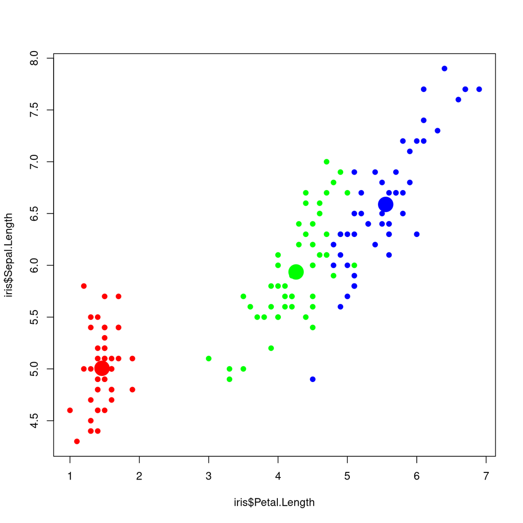

```r
# Draw the scatterplot, using ny_cols as color argument
plot(iris$Petal.Length,
     iris$Sepal.Length,
     pch=19,
     col=my_cols)


# plot the points marking the means:
points(mPL,
       mSL,
       pch=19,
       col=species_cols,
       cex=3
       )
```

### Exercise 7 [complex]

Similar to the “Organs Distributions” example, combine three histograms in one plot, one for each of the 3 species in the iris dataset. Color the 3 histograms differently. Add a title and a legend to the plot. Can you position the legend towards the top middle, such that it does not overlap the histograms?

The complexity of this is in part not a question of plotting, but of programmatically producing the input to the plot!

Hints:

- I suggest to use `tapply()` to slice the iris dataset into a named list of per-species datasets. See `?tapply`. If `x` is an index column in a data.frame `df` (like `Species` in our case), then `l <- tapply(df, ~x, data.frame`) returns a list named `l`, with as many elements as there are different `x` values. Each list element holds a subset of `df` with a fixed `x` value. In the `tapply` call, the third parameter is a function, to be a applied to the subset defined by the current index value. Here, the `data.frame()` function insists that the subset is to be returned as a data.frame rather than a list.

Can you transfer this to the present case?

- Once you have the list, the scheme for plotting the histograms is as follows
  - Plot the histogram of ``l[[1]]`. This initializes the plot, which means that you have to set global parameters like the title, the x axis label, and the x range (`xlim`). Keep in mind that the histograms of all species must fit on the canvas!
  - Loop over the list elements 2 and 3 and plot their histograms.
- For the legend, see the “How To Draw a Histogram” example. However if you just copy the example, then the legend will partly cover the histograms. Use `?legend` and check the meaning of the `x` and `y` arguments. Try to find an optimal position!

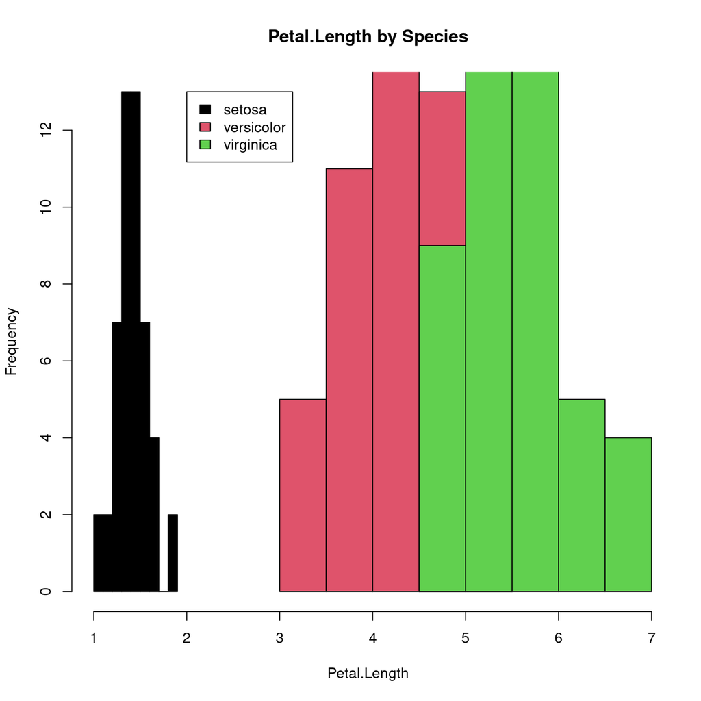

```r
# split the iris data.frame by species (the result is a named list):
iris_by_species <-
  tapply(iris,
         ~Species,
         data.frame)

# The histogram of the first species initiates the plot:
# global parameters must be set here
hist(iris_by_species[[1]]$Petal.Length,
     col = 1,

     ## mind that the final plot will cover the
     ## entire species range!
     xlim=range(iris$Petal.Length),
     xlab="Petal.Length",
     main = "Petal.Length by Species"
)
# plot the remaining species histograms in a loop:
for(i in 2:length(iris_by_species))
    hist(iris_by_species[[i]]$Petal.Length,
         col = i,
     add=TRUE
    )
# plot the legend at an optimal position:
legend("topright",
       legend=levels(iris$Species),
       #fill=c(rgb(1, 0, 0, alpha=0.5),
       #       rgb(0, 0, 1, alpha=0.5))
       fill=1:3,
       x=2,
       y=13
       )
```

```r
library(ggplot2)
```

### Exercise 8: Simple Scatter Plot

- **Objective**: Create a scatter plot of `Sepal.Length` vs. `Sepal.Width` from the `iris` dataset.
- **Difficulty**: Easy
- **Estimated Time**: 5-10 minutes (for beginners)

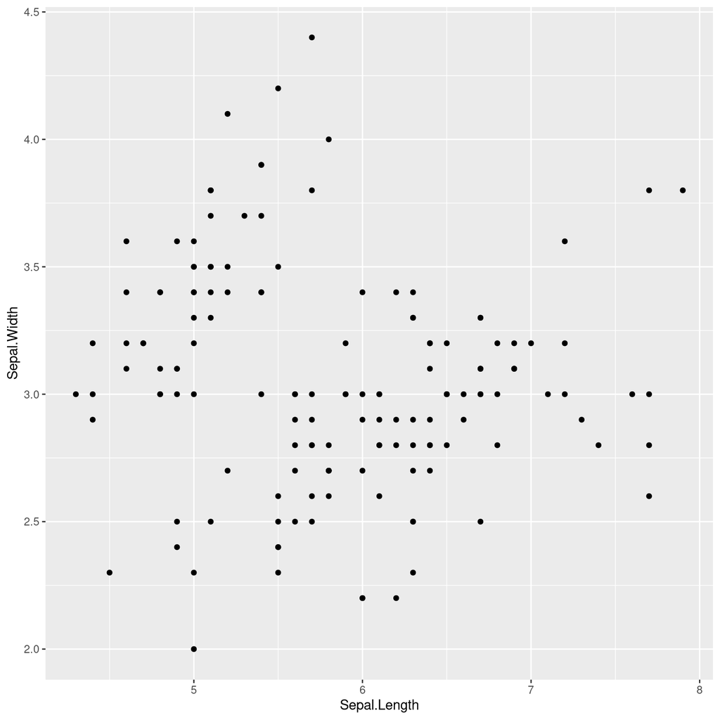

```r
# Load the iris dataset
data(iris)

# Create a scatter plot with ggplot
ggplot(iris, aes(x = Sepal.Length, y = Sepal.Width)) +
  geom_point()
```

- **Your Task**: Color the points by `Species` and add labels to the x and y axes.
- **Difficulty**: Easy
- **Estimated Time**: 5-10 minutes

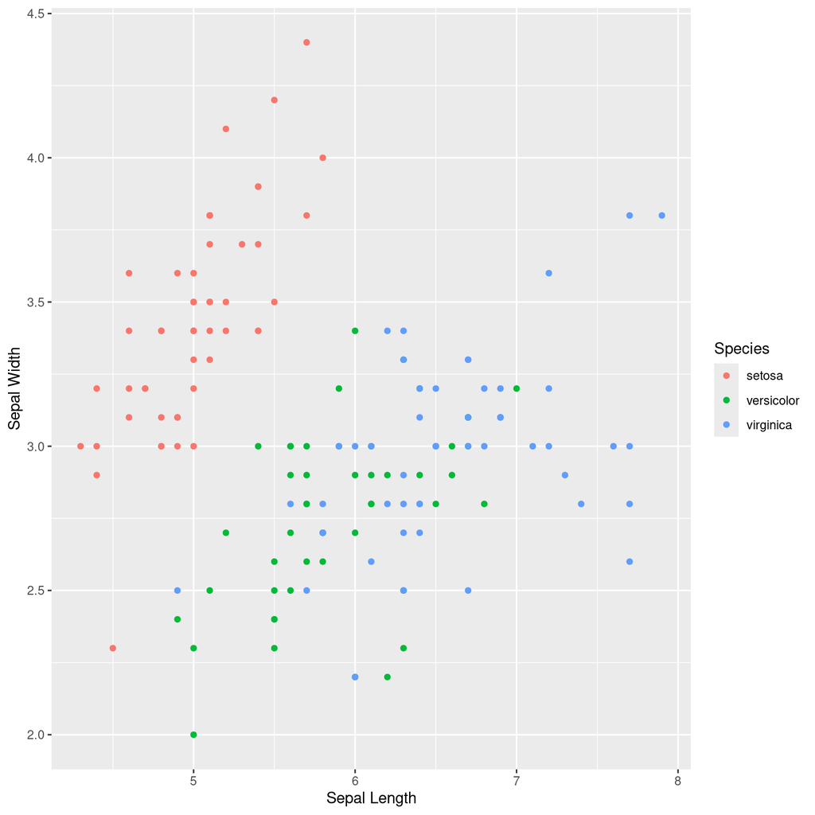

```r
# Solution to Exercise 1
ggplot(iris, aes(x = Sepal.Length, y = Sepal.Width, color = Species)) +
  geom_point() +
  xlab("Sepal Length") +
  ylab("Sepal Width")
```

### Exercise 9: Adding Titles and Labels

- **Objective**: Use the plot from Exercise 1 and add a title, x-axis label, and y-axis label.
- **Difficulty**: Easyy
- **Estimated Time**: 5 minutes

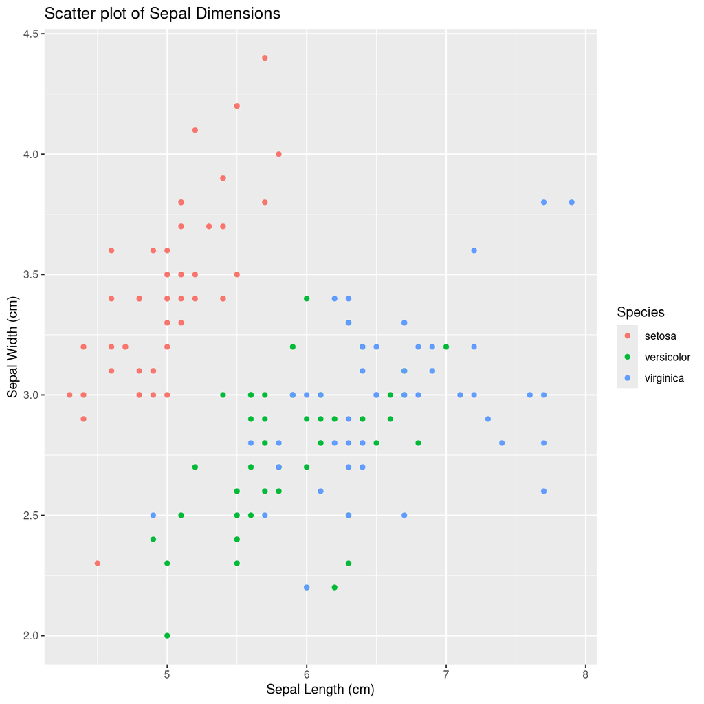

```r
# Create scatter plot with labels
ggplot(iris, aes(x = Sepal.Length, y = Sepal.Width, color = Species)) +
  geom_point() +
  ggtitle("Scatter plot of Sepal Dimensions") +
  xlab("Sepal Length (cm)") +
  ylab("Sepal Width (cm)")
```

- **Your Task**: Modify the plot to include a subtitle and caption.
- **Difficulty**: Easy
- **Estimated Time**: 5 minutes

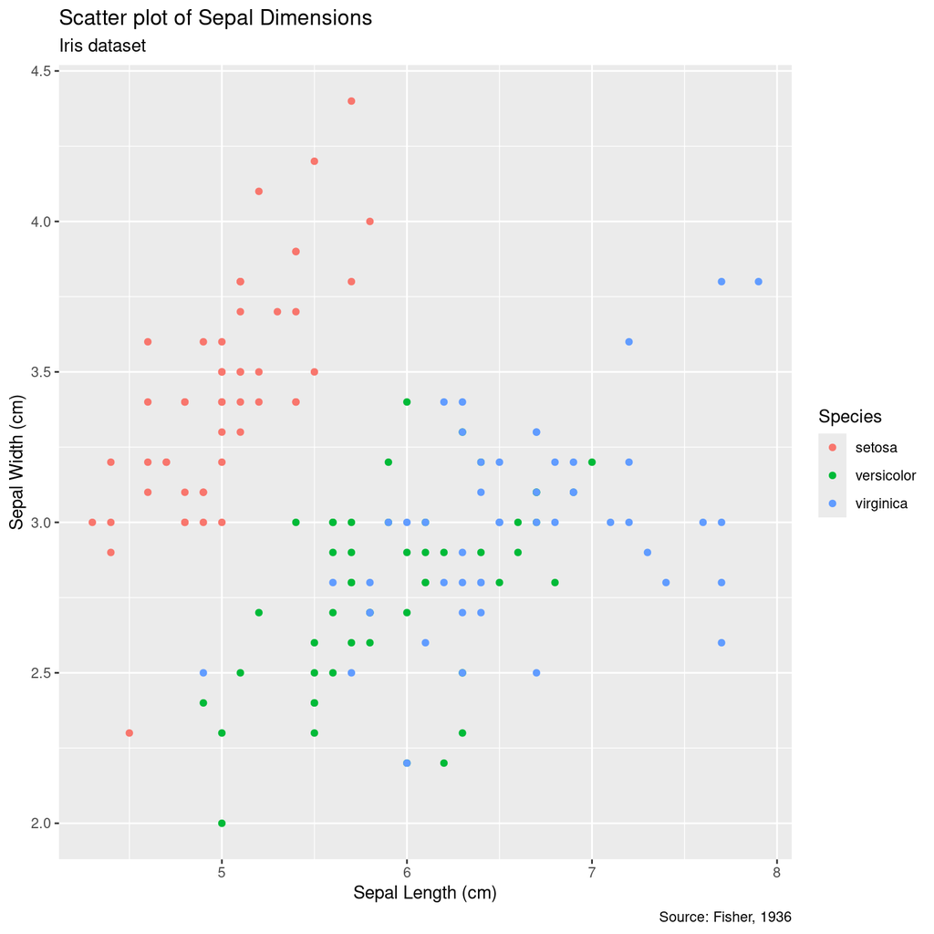

```r
# Solution to Exercise 2
ggplot(iris, aes(x = Sepal.Length, y = Sepal.Width, color = Species)) +
  geom_point() +
  ggtitle("Scatter plot of Sepal Dimensions") +
  xlab("Sepal Length (cm)") +
  ylab("Sepal Width (cm)") +
  labs(subtitle = "Iris dataset", caption = "Source: Fisher, 1936")
```

### Exercise 10: Bar Plot of Species Count

- **Objective**: Create a bar plot showing the count of each species in the `iris` dataset.
- **Difficulty**: Easy
- **Estimated Time**: 5-10 minutes

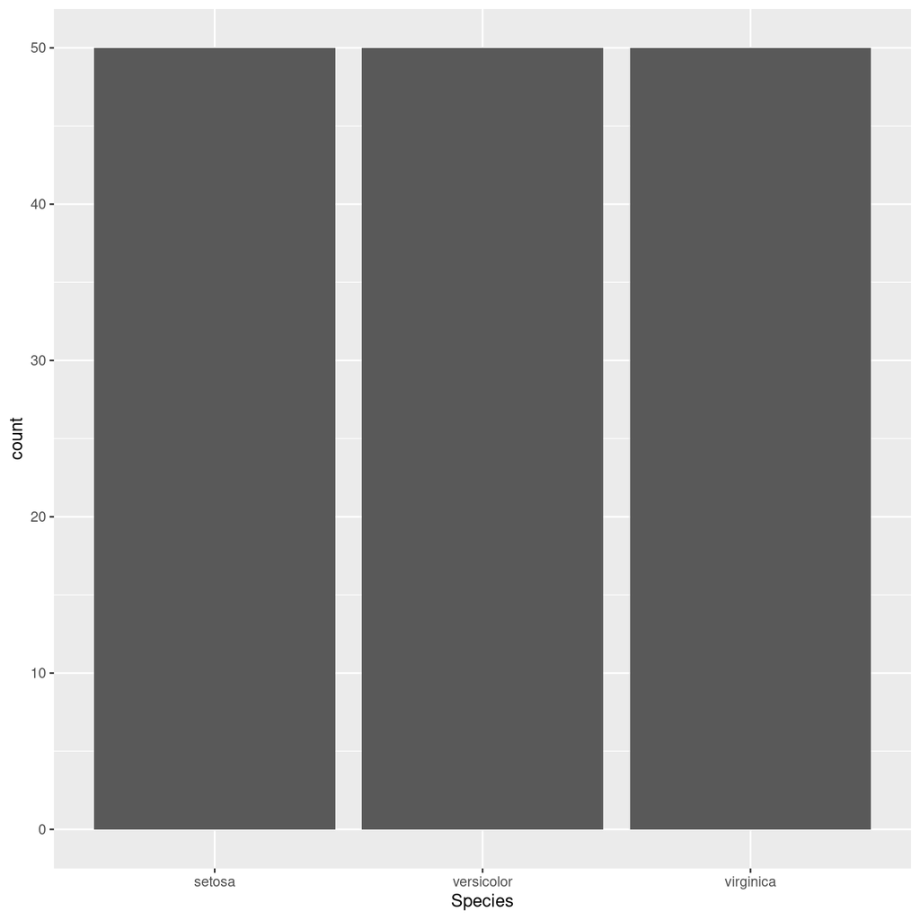

```r
# Create a bar plot of species count
ggplot(iris, aes(x = Species)) +
  geom_bar()
```

- **Your Task**: Modify the plot to use different colors for each species.
- **Difficulty**: Easy
- **Estimated Time**: 5-10 minutes

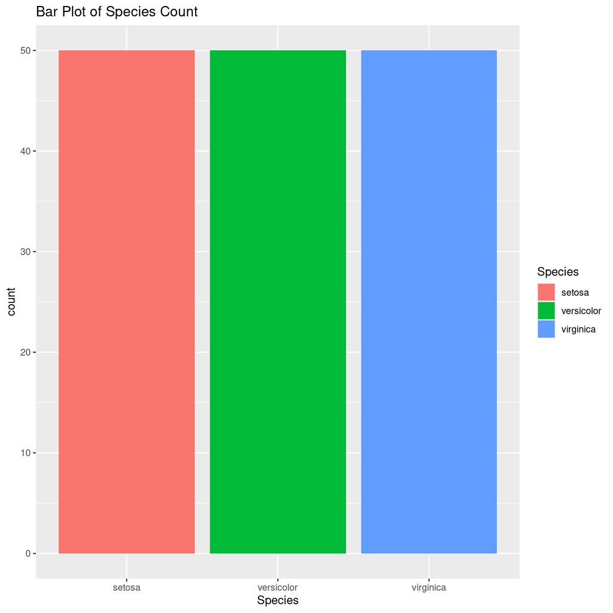

```r
# Solution to Exercise 3
ggplot(iris, aes(x = Species, fill = Species)) +
  geom_bar() +
  labs(title = "Bar Plot of Species Count")
```

### Exercise 11: Boxplot of Petal Length by Species

- **Objective**: Create a boxplot of `Petal.Length` for each species in the `iris` dataset.
- **Difficulty**: Medium
- **Estimated Time**: 5-10 minutes

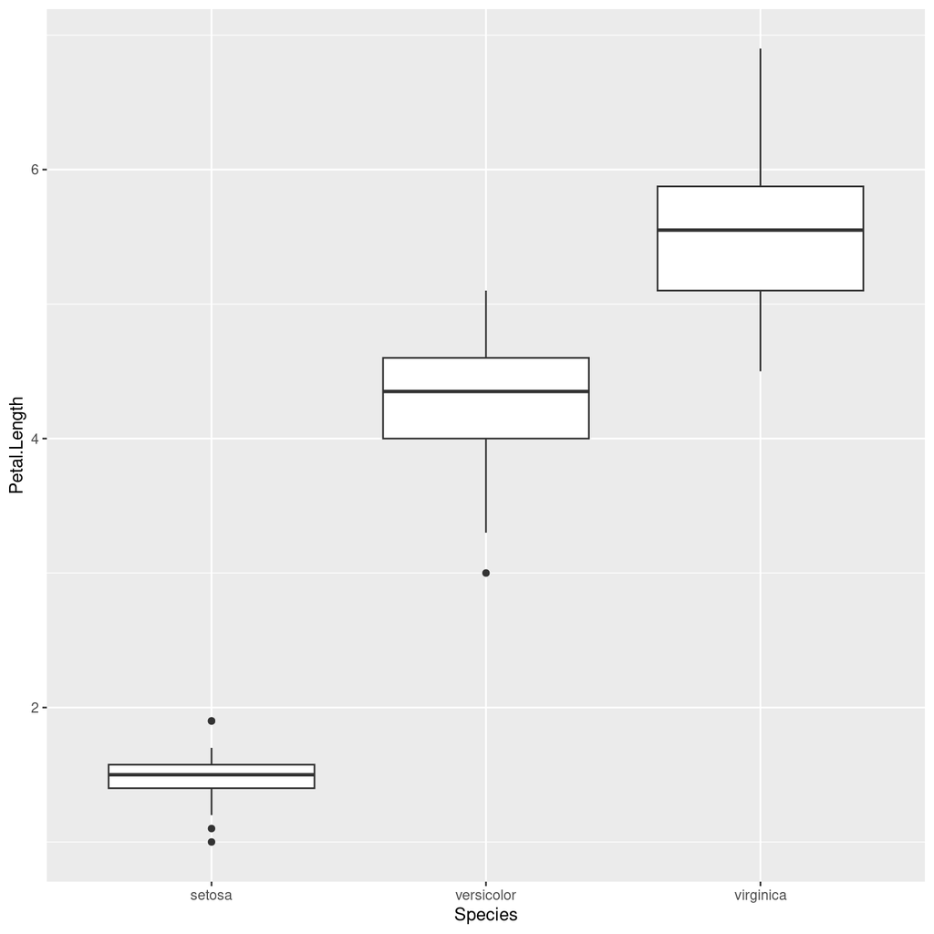

```r
# Create a boxplot of Petal Length by Species
ggplot(iris, aes(x = Species, y = Petal.Length)) +
  geom_boxplot()
```

- **Your Task**: Customize the plot by changing the colors of the boxplots and adding a theme.
- **Difficulty**: Medium
- **Estimated Time**: 10-15 minutes

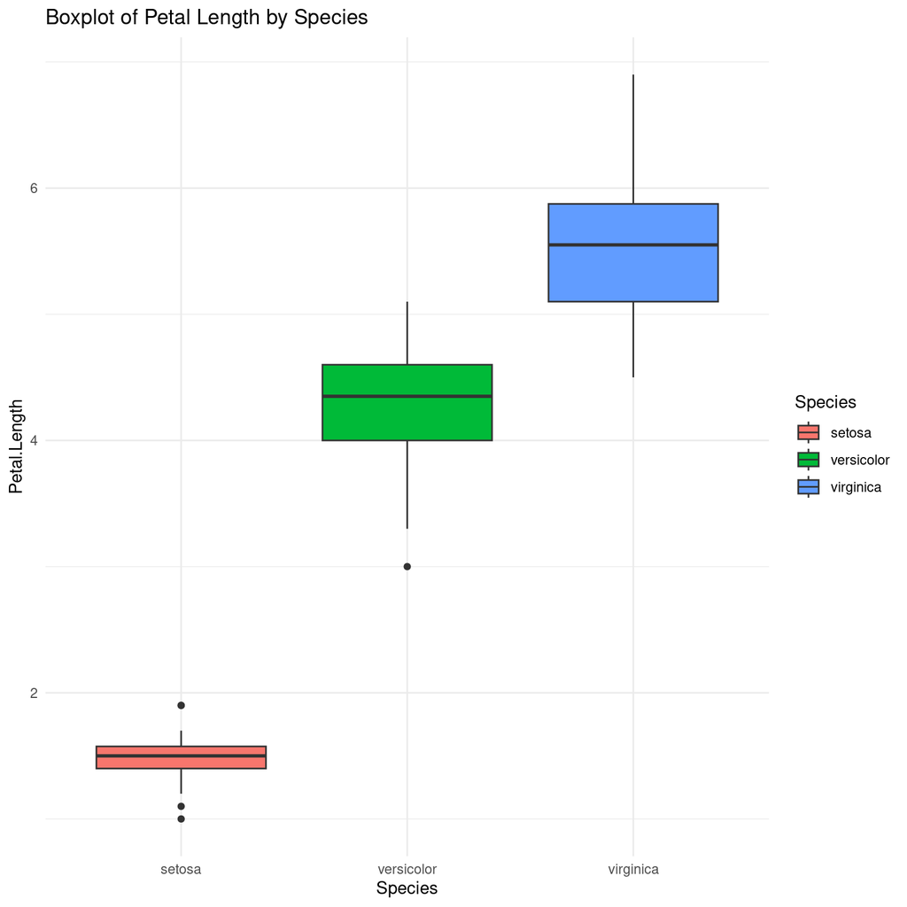

```r
# Solution to Exercise 4
ggplot(iris, aes(x = Species, y = Petal.Length, fill = Species)) +
  geom_boxplot() +
  theme_minimal() +
  labs(title = "Boxplot of Petal Length by Species")
```

### Exercise 12: Histogram of Sepal Length

- **Objective**: Create a histogram of `Sepal.Length` in the `iris` dataset.
- **Difficulty**: Easy
- **Estimated Time**: 5-10 minutes

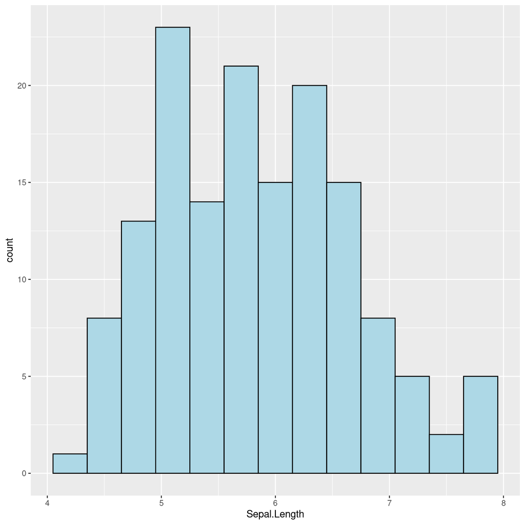

```r
# Create a histogram of Sepal Length
ggplot(iris, aes(x = Sepal.Length)) +
  geom_histogram(binwidth = 0.3, fill = "lightblue", color = "black")
```

- **Your Task**: Change the number of bins and add a title to the histogram.
- **Difficulty**: Easy
- **Estimated Time**: 5-10 minutes

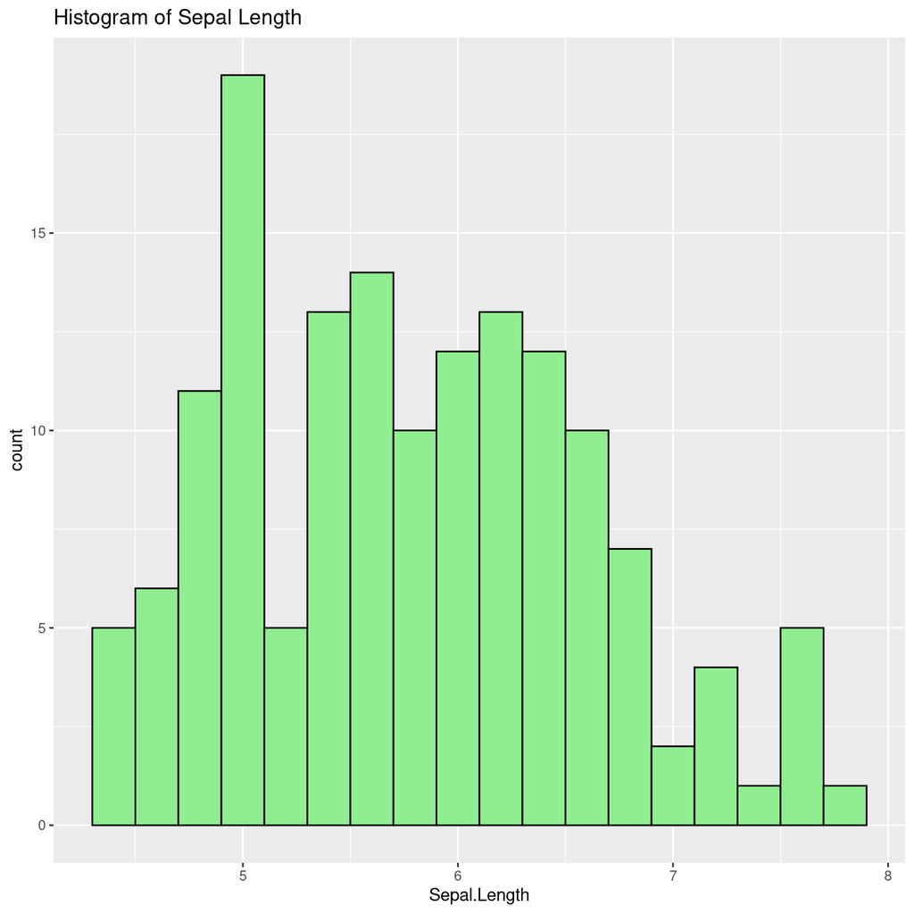

```r
# Solution to Exercise 5
ggplot(iris, aes(x = Sepal.Length)) +
  geom_histogram(binwidth = 0.2, fill = "lightgreen", color = "black") +
  labs(title = "Histogram of Sepal Length")
```

### Exercise 13: Faceting by Species

- **Objective**: Use faceting to create multiple scatter plots for each species in the `iris` dataset.
- **Difficulty**: Medium
- **Estimated Time**: 10 minutes

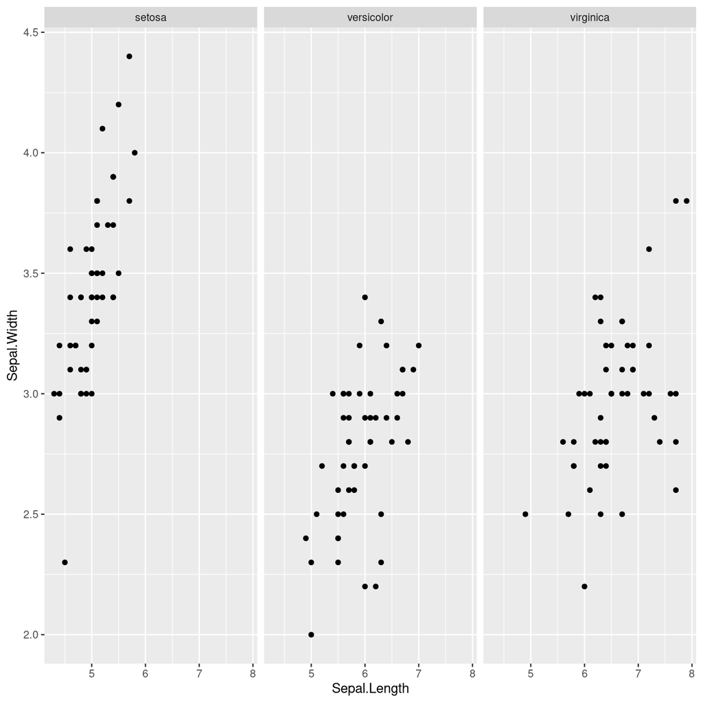

```r
# Facet scatter plot by Species
ggplot(iris, aes(x = Sepal.Length, y = Sepal.Width)) +
  geom_point() +
  facet_wrap(~ Species)
```

- **Your Task**: Customize the facet labels and add a theme to the plot.
- **Difficulty**: Medium
- **Estimated Time**: 15 minutes

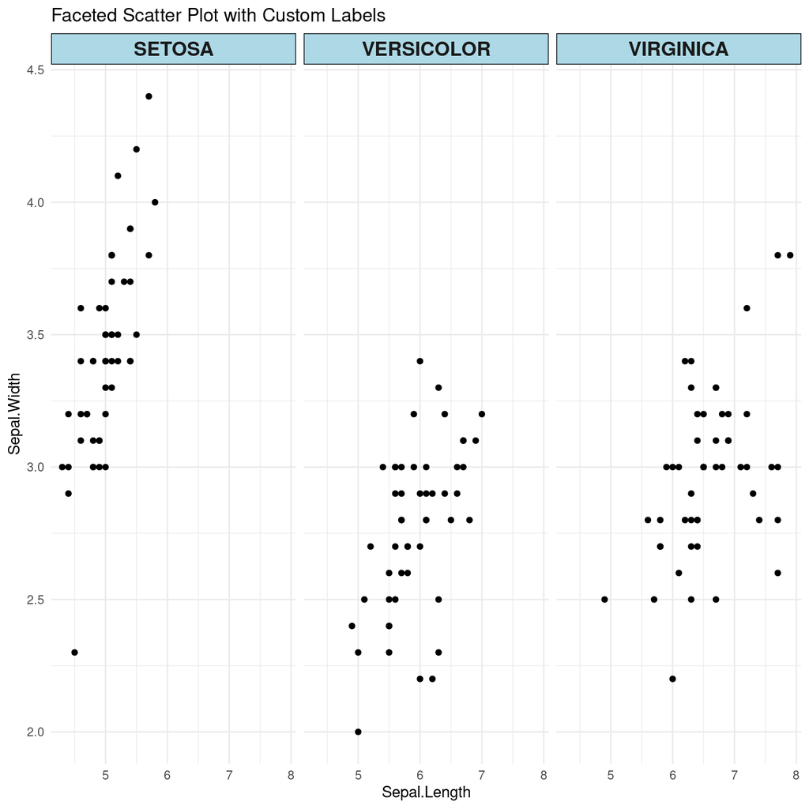

```r
# Solution to Exercise 6
ggplot(iris, aes(x = Sepal.Length, y = Sepal.Width)) +
  geom_point() +
  facet_wrap(~ Species,
             labeller = labeller(Species = toupper),             # 1. Uppercase labels
             nrow = 1) +                                         # 2. Set facets in a single row
  theme_minimal() +                                              # 3. Minimal theme
  theme(strip.text = element_text(face = "bold", size = 14),      # 4. Bold and larger facet labels
        strip.background = element_rect(fill = "lightblue")) +    # 5. Change background color of facet labels
  labs(title = "Faceted Scatter Plot with Custom Labels")
```